# Logboek

Stijn Vermeulen

2024-05-06

## Library’s

```r
library(ggplot2)
library(dplyr)
library(cowplot)
library(ggcorrplot)
library(tidyr)
```

# Introductie

Gist is een levensvorm die vooral wordt gebruikt voor bakken, maar ze zijn ook interessant met hun groei en levensduur. Daarom willen wij weten wat er gebeurt als je gist in verschillende concentraties suiker en zout zet. Zou de gist doodgaan door een te hoge suiker concentratie of als er geen zout aanwezig is? Dit logboek is om mijn gedachten te laten zien gedurende dit project.

## May 6 2024

Vandaag onderzoek ik hoe bakkersgist reageert op zoute omgevingen, bijvoorbeeld hoe hun productie van alcohol veranderd.

Op google scholar zoek ik voornamelijk met de zoektermen: “bakers Yeast”, “Yeast”, “Salt”, “Saltstress”

een gevonden bron over brood maken met zout-gestrest bakkersgist: https://ift.onlinelibrary.wiley.com/doi/full/10.1111/j.1750-3841.2009.01337.x

## May 7 2024

Vandaag vervolg ik het brononderzoek die op 6 mei is begonnen.

Ik begin met te verder lezen van de bron die ik op 6 mei had gevonden: De bron is vaag in het stukje materialen, maar het geeft goede informatie voor de efficientie van gist onder zoutgeinduceerde stress (in dit geval 7% NaCl oplossing). In dit geval is produceerdt de gist 2.8 keer zo veel glycerol dan de controle groep. (gevonden bij “Results and discussion”, Table 3)

Een andere bron over de groei van gist onder zoutrijke omgevingen: https://www.sciencedirect.com/science/article/pii/S1978301917302085

In dit experiment werden de concentraties 0.5, 0.75 en 1.0M NaCl gebruikt. Bij 1.0M gingen vrijwel alle gistcellen (van Z. bisporus) dood, en bij de andere concentraties groeide de gist duidelijk minder snel dan bij de groep zonder zout

Op basis van deze bronnen denk ik dat de gisten onder zoutstress meer CO2 gaan produceeren, maar ook veel sneller dood gaan. Dus in het begin van het experiment zullen de gisten bij zout meer CO2 produceren dan bij de suikergroepen, maar die productie valt ook sneller af wat er voor zorgt dat de totale productie van de zoutgroepen kleiner is dan de suikergroepen.

## May 13 2024

Vandaag ga ik het protocool maken, van advies die we hadden gekregen van het magazijn op zernikkeplein 11.

Ik heb het schudden van het gistmengsel aan het protocool toegevoegd op het advies van mijn teamgenoten. Dit gebeurdt om het halfuur zodat het gist goed kan blijven werken over langere tijden.

Ik heb de uitvoering veranderd naar een stapgewijze schrijfwijze, zodat het protocool makkelijker te volgen is.

## May 14 2024 + May 15 2024 + May 16 2024

Ik ga de komende dagen beginnen met het maken van een voorbeeld Heatmap, dit doe ik zodat ik de code al heb voor de uiteindelijke data.

Ik wil weten waar ik zit zodat ik weet waar ik zit in vergelijking met de data

```r
getwd()
```

```
## [1] "/home/user/Documents/ProjectWetenschappelijkeCyclus/analysis"
```

Ik zit in dezelfde map als de data, dus ik hoef niks toe te voegen aan het pad

```r
dataset_suiker <- read.csv(file = "./data/data_gist_testsheet_suiker.csv")
dataset_zout <- read.csv(file = "./data/data_gist_testsheet_zout.csv")

head(dataset_suiker)
```

```
##   experiment_id meting_id suiker_concentraties gist temperatuur productie_co2
## 1            S1         1                  100    2          21           3.0
## 2            S2         1                  150    2          21           5.0
## 3            S3         1                  200    2          21           6.0
## 4           Sd1         1                  100    2          21           3.5
## 5           Sd2         1                  150    2          21           5.5
## 6           Sd3         1                  200    2          21           6.5
##   datum tijd
## 1    NA   NA
## 2    NA   NA
## 3    NA   NA
## 4    NA   NA
## 5    NA   NA
## 6    NA   NA
```

```r
head(dataset_zout)
```

```
##   experiment_id meting_id suiker_concentraties gist temperatuur productie_co2
## 1            Z1         1                    1    2          21          4.50
## 2            Z2         1                    2    2          21          7.50
## 3            Z3         1                    4    2          21          9.00
## 4           Zd1         1                    1    2          21          5.25
## 5           Zd2         1                    2    2          21          8.25
## 6           Zd3         1                    4    2          21          9.75
##   datum tijd
## 1     1   NA
## 2     1   NA
## 3     1   NA
## 4     1   NA
## 5     1   NA
## 6     1   NA
```

Deze data is tidy, dus ik hoef niks te doen met de data zelf.

Ik sla het op in een ander variabele zodat ik niet bij het testen de hele tijd de data opnieuw uit het exel bestand te halen en ik gebruik as.data.frame zodat ik zeker weet dat ik een data frame heb

```r
suiker_df <- as.data.frame(dataset_suiker)
zout_df <- as.data.frame(dataset_zout)

head(suiker_df)
```

```
##   experiment_id meting_id suiker_concentraties gist temperatuur productie_co2
## 1            S1         1                  100    2          21           3.0
## 2            S2         1                  150    2          21           5.0
## 3            S3         1                  200    2          21           6.0
## 4           Sd1         1                  100    2          21           3.5
## 5           Sd2         1                  150    2          21           5.5
## 6           Sd3         1                  200    2          21           6.5
##   datum tijd
## 1    NA   NA
## 2    NA   NA
## 3    NA   NA
## 4    NA   NA
## 5    NA   NA
## 6    NA   NA
```

```r
head(zout_df)
```

```
##   experiment_id meting_id suiker_concentraties gist temperatuur productie_co2
## 1            Z1         1                    1    2          21          4.50
## 2            Z2         1                    2    2          21          7.50
## 3            Z3         1                    4    2          21          9.00
## 4           Zd1         1                    1    2          21          5.25
## 5           Zd2         1                    2    2          21          8.25
## 6           Zd3         1                    4    2          21          9.75
##   datum tijd
## 1     1   NA
## 2     1   NA
## 3     1   NA
## 4     1   NA
## 5     1   NA
## 6     1   NA
```

Nu hebben we een data frame, maar er zit data in wat niet relevant is voor deze visualisatie Datum en Tijd worden gelogd voor duidelijkheid, maar staan hier leeg. Gist en Temperatuur zijn bij dit voorbeeld constant, dus die kunnen er ook uit.

```r
suiker_df <- suiker_df[c(1, 2, 3, 6)]
zout_df <- zout_df[c(1, 2, 3, 6)]

str(suiker_df)
```

```
## 'data.frame':    42 obs. of  4 variables:
##  $ experiment_id       : chr  "S1" "S2" "S3" "Sd1" ...
##  $ meting_id           : int  1 1 1 1 1 1 2 2 2 2 ...
##  $ suiker_concentraties: int  100 150 200 100 150 200 100 150 200 100 ...
##  $ productie_co2       : num  3 5 6 3.5 5.5 6.5 4 7 9 4.5 ...
```

```r
str(zout_df)
```

```
## 'data.frame':    42 obs. of  4 variables:
##  $ experiment_id       : chr  "Z1" "Z2" "Z3" "Zd1" ...
##  $ meting_id           : int  1 1 1 1 1 1 2 2 2 2 ...
##  $ suiker_concentraties: int  1 2 4 1 2 4 1 2 4 1 ...
##  $ productie_co2       : num  4.5 7.5 9 5.25 8.25 9.75 6 10.5 13.5 6.75 ...
```

Er lijken geen NA’s in te zitten en de variabelen die ik plot(Meeting, Concentratie en CO2) zijn numeric. De namen wil ik wel even veranderen, zodat er geen raare tekens of spaties er in zitten.

```r
names(suiker_df) <- c("ID", "Meting", "Suiker", "CO2")
names(zout_df) <- c("ID", "Meting", "Zout", "CO2")

head(suiker_df)
```

```
##    ID Meting Suiker CO2
## 1  S1      1    100 3.0
## 2  S2      1    150 5.0
## 3  S3      1    200 6.0
## 4 Sd1      1    100 3.5
## 5 Sd2      1    150 5.5
## 6 Sd3      1    200 6.5
```

```r
head(zout_df)
```

```
##    ID Meting Zout  CO2
## 1  Z1      1    1 4.50
## 2  Z2      1    2 7.50
## 3  Z3      1    4 9.00
## 4 Zd1      1    1 5.25
## 5 Zd2      1    2 8.25
## 6 Zd3      1    4 9.75
```

Nu zijn de namen goed, ik wil nog wel even de summary zien.

```r
summary(suiker_df)
```

```
##       ID                Meting      Suiker         CO2
##  Length:42          Min.   :1   Min.   :100   Min.   : 3.000
##  Class :character   1st Qu.:2   1st Qu.:100   1st Qu.: 6.125
##  Mode  :character   Median :4   Median :150   Median : 8.000
##                     Mean   :4   Mean   :150   Mean   : 7.917
##                     3rd Qu.:6   3rd Qu.:200   3rd Qu.:10.000
##                     Max.   :7   Max.   :200   Max.   :11.500
```

```r
summary(zout_df)
```

```
##       ID                Meting       Zout            CO2
##  Length:42          Min.   :1   Min.   :1.000   Min.   : 2.500
##  Class :character   1st Qu.:2   1st Qu.:1.000   1st Qu.: 4.062
##  Mode  :character   Median :4   Median :2.000   Median : 6.375
##                     Mean   :4   Mean   :2.333   Mean   : 8.524
##                     3rd Qu.:6   3rd Qu.:4.000   3rd Qu.:13.312
##                     Max.   :7   Max.   :4.000   Max.   :18.000
```

Het ID, de meting en de concentratie zijn niet relevant voor de summary, maar de CO2 data lijkt wel interessant. Bij suiker zit het eerste kwartiel zit verder van het minimum dan het derde kwartiel bij het maximum, maar bij het zout zit het andersom. Bij suiker is de mediaan vrijwel hetzelfde als het gemiddelde, maar bij zout zit er meer dan 2 g/L tussen.

Nu ga ik het visualiseren

```r
# Nieuwe variabelen die ik dan makkelijk kan veranderen
viz_suiker_df <- suiker_df
viz_zout_df <- zout_df

# Ik combineer het ID met de concentratie zodat ik die samen op een as kan hebben
viz_suiker_df$ID <- paste(viz_suiker_df$ID, viz_suiker_df$Suiker, sep = "-")
viz_zout_df$ID <- paste(viz_zout_df$ID, viz_zout_df$Zout, sep = "-")

# Ik maak hier twee verschillende heatmaps die ik later samen ga zetten
suiker_plot <- ggplot(data = viz_suiker_df,
            mapping = aes(x = Meting, y = ID, fill = CO2)) +
            geom_tile() +
            labs(y = "Meting + concentratie(g/L)", x = "Tijd(h)") +
            scale_fill_gradient(limits = c(0, 20), low = "white", high = "red") +
            theme_minimal()

zout_plot <- ggplot(data = viz_zout_df,
            mapping = aes(x = Meting, y = ID, fill = CO2)) +
            geom_tile() +
            labs(y = "Meting + concentratie(g/L)", x = "Tijd(h)") +
            scale_fill_gradient(limits = c(0, 20), low = "white", high = "red") +
            theme_minimal()

# Hier geef ik nog een keer de concentratie bij het ID voor duidelijkheid
for (i in 1:6){
    cat(suiker_df[i, 1], "=", suiker_df[i, 3], "g/L suiker     ")
    cat(zout_df[i, 1], "=", zout_df[i, 3], "g/L zout\n")
}
```

```
## S1 = 100 g/L suiker     Z1 = 1 g/L zout
## S2 = 150 g/L suiker     Z2 = 2 g/L zout
## S3 = 200 g/L suiker     Z3 = 4 g/L zout
## Sd1 = 100 g/L suiker     Zd1 = 1 g/L zout
## Sd2 = 150 g/L suiker     Zd2 = 2 g/L zout
## Sd3 = 200 g/L suiker     Zd3 = 4 g/L zout
```

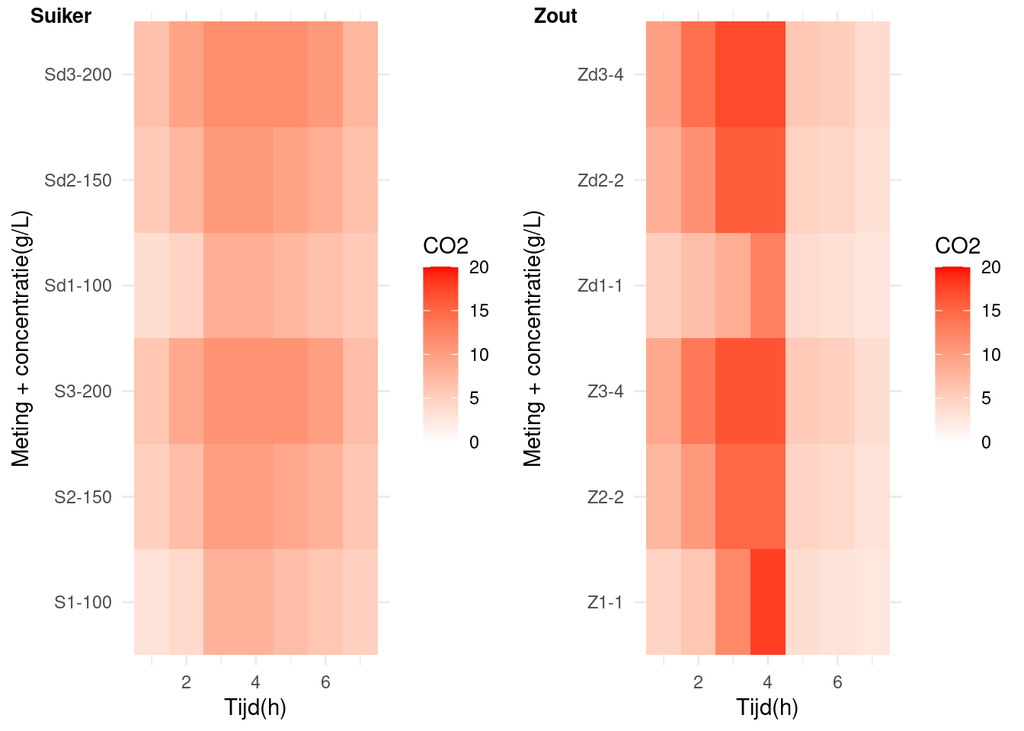

```r
# Ik gebruik hier de cowplot library om de twee heatmaps naast elkaar te zetten
plot_grid(suiker_plot, zout_plot, labels = c("Suiker", "Zout"), label_size = 10, align = c("v"))
```

Op 14 Mei hebben wij een test run gedaan. Hierin hadden we gevonden dat het handiger is om de gist als laatst toe te voegen en eerst het waterslot te maken. Deze informatie heb ik later toegevoegd aan het protocool

Voor meer details kun je kijken in het logboek van Ivar.

## May 17 2024

Vandaag wordt het experiment gedaan.

Eerst voelde alles wat chaotisch, doordat er meer gist in de mengsels waren gedaan dan vooraf gepland(3g -> 7g). Er was veel meer gasproductie dan verwacht en daardoor hadden we besloten om de maatcilinders te hervullen als er teveel gasproductie was. Dit werd dan genoteerd in de spreadsheet onder het kopje “Opmerking”. We hebben daarnaast ook het interval tussen meetpunten ingekort naar een keer per 15 minuten in te plaats van een keer per uur. We zijn uiteindelijk gestop na 11 meetpunten voor suiker en zout.

De data is te vinden in dit Document en dit Document

## May 21 2024

Vandaag hebben wij een taakvedelen gemaakt voor de komende weken. Ik ga de heatmap visualiseren en de presentatie over heatmaps maken.

Voor het maken van de heatmap moet ik eerst wachten tot Ivar de data van het experiment tidy heeft gemaakt.

Wikipedia over de heatmap: https://en.wikipedia.org/wiki/Heat_map

Het lijkt dat er 2 soorten heatmap te zijn: Een die bijvoorbeeld gaat over een kaart van de wereld heet een `spatial heatmap` En een `grid heatmap` heeft een grid.

Er zijn wel twee soorten grid heatmap: Clusterd, die wij hebben en een Correlogram, die een driehoeksvorm heeft doordat het combinatie uit een lijst vergelijkt en A-B == B-A.

## May 22 2024

Vandaag wil ik verder met het onderzoek naar heatmaps

Ik wil vooral kijken naar mogelijke limitaties met het gebruiken van heatmaps

Ik denk dat veel datapunten het mogelijk moeilijk kunnen maken om de data te interperteren

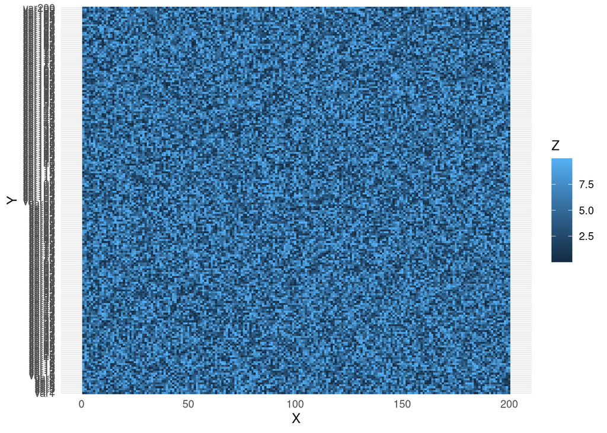

```r
x <- 1:200
y <- paste0("var", seq(1:200))
data <- expand.grid(X=x, Y=y)
data$Z <- runif(40000, 0, 10)

ggplot(data, aes(X, Y, fill= Z)) +
  geom_tile() +
  theme_minimal()
```

Dit is inderdaad onoverzichtelijk, maar vooral bij de y-as, wat nog aan te passen valt. Het is waarschijnlijk niet een echte limitatie, omdat je kan inzoomen op de heatmap en de assen een beetje kan aanpassen zodat het leesbaar is.

Een andere limitatie lijkt me als er een uitschieter is, die de kleuren veranderen

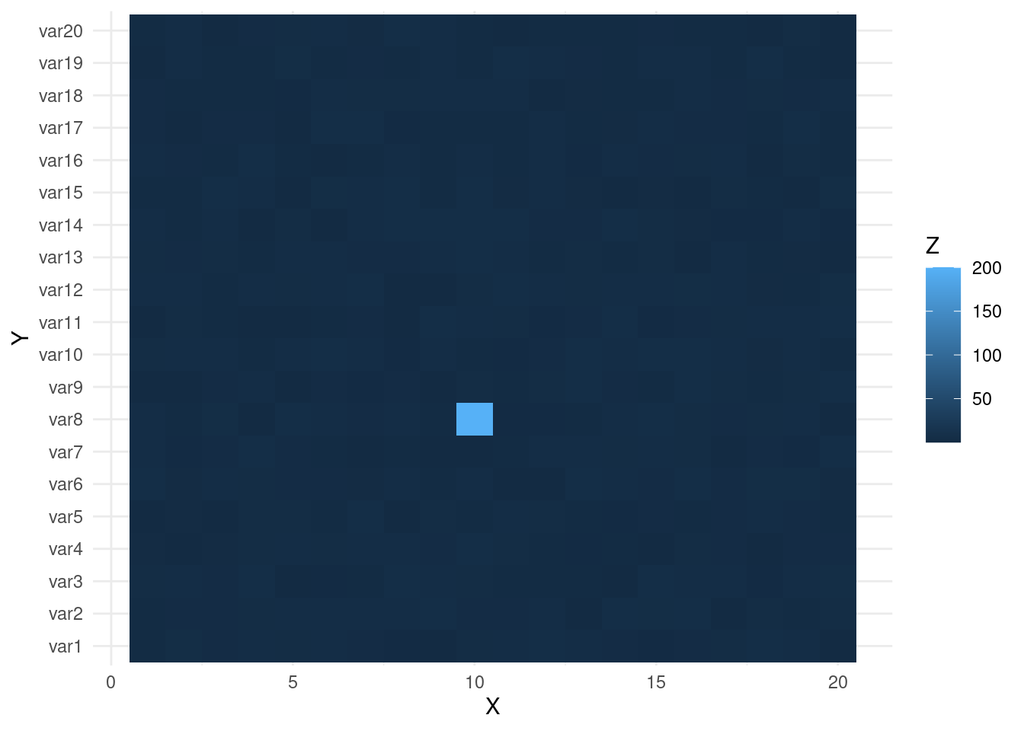

```r
x <- 1:20
y <- paste0("var", seq(1:20))
data <- expand.grid(X=x, Y=y)
data$Z <- runif(400, 0, 5)
data$Z[150] <- c(200)

ggplot(data, aes(X, Y, fill= Z)) +
  geom_tile() +
  theme_minimal()
```

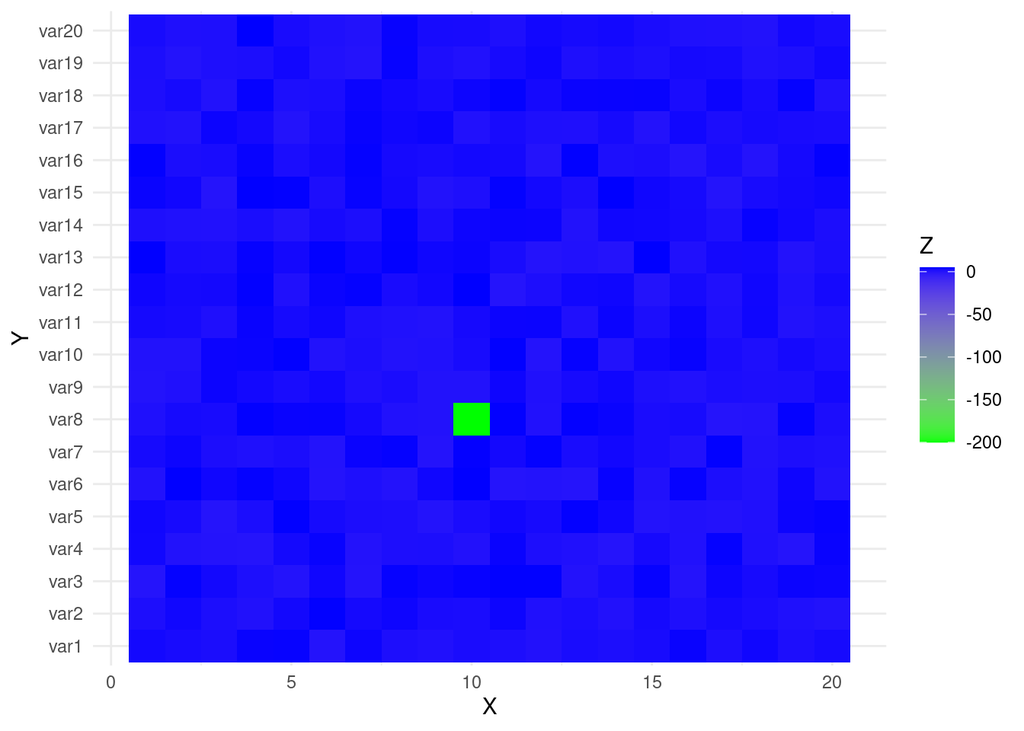

```r
x <- 1:20
y <- paste0("var", seq(1:20))
data <- expand.grid(X=x, Y=y)
data$Z <- runif(400, 0, 5)
data$Z[150] <- c(-200)

ggplot(data, aes(X, Y, fill= Z)) +
  geom_tile() +
  scale_fill_gradient(low = "green", high = "blue") +
  theme_minimal()
```

Het klopt, de grote verandering zorgt er inderdaad voor dat de rest van de data niet te lezen is. Deze valt waarschijnlijk wel op te merken voordat de data wordt gevisualiseerd, maar het is alsnog een punt om op te letten.

Ik denk dat de iris.csv dataset misschien nog wat interessante limitatie punten kan geven

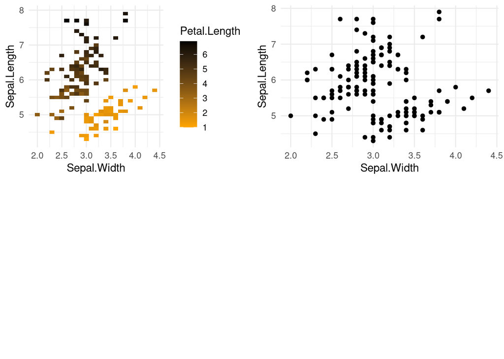

```r
data <- datasets::iris

save1 <- ggplot(data, aes(Sepal.Width, Sepal.Length, fill= Petal.Length)) +
           geom_tile() +
           scale_fill_gradient(low = "orange", high = "black") +
           theme_minimal()

save2 <- ggplot(data, aes(Sepal.Width, Sepal.Length)) +
            geom_point() +
            theme_minimal()

plot_grid(save1, save2, allign = c("v"))
```

Hoe het zo is zijn er veel punten zonder waarde. Deze punten laat heatmap er uit. Nu zie je een scatterplot met nog een as in de vorm van kleur.

Je kunt het ook op een andere manier doen:

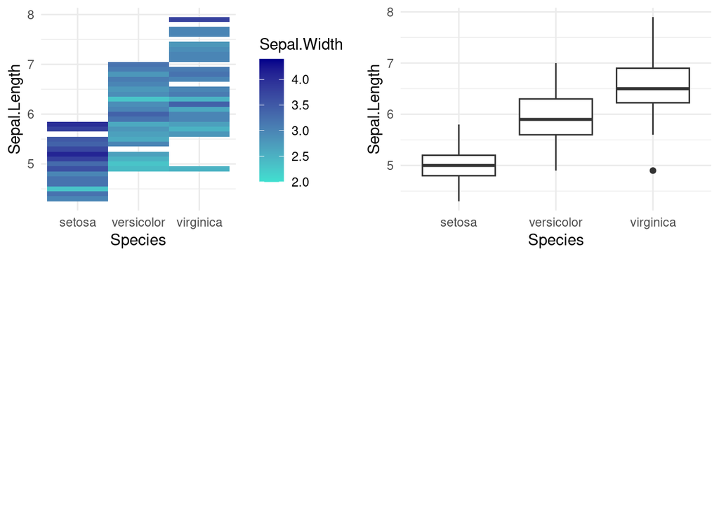

```r
data <- datasets::iris

save1 <- ggplot(data, aes(Species, Sepal.Length, fill= Sepal.Width)) +
          geom_tile() +
          scale_fill_gradient(low = "turquoise", high = "darkblue") +
          theme_minimal()

save2 <- ggplot(data, aes(Species, Sepal.Length)) +
          geom_boxplot() +
          theme_minimal()

plot_grid(save1, save2, allign = c("v"))
```

Nu heb je een boxplot met een extra demensie in de vorm van kleur.

Even kijken naar een andere dataset

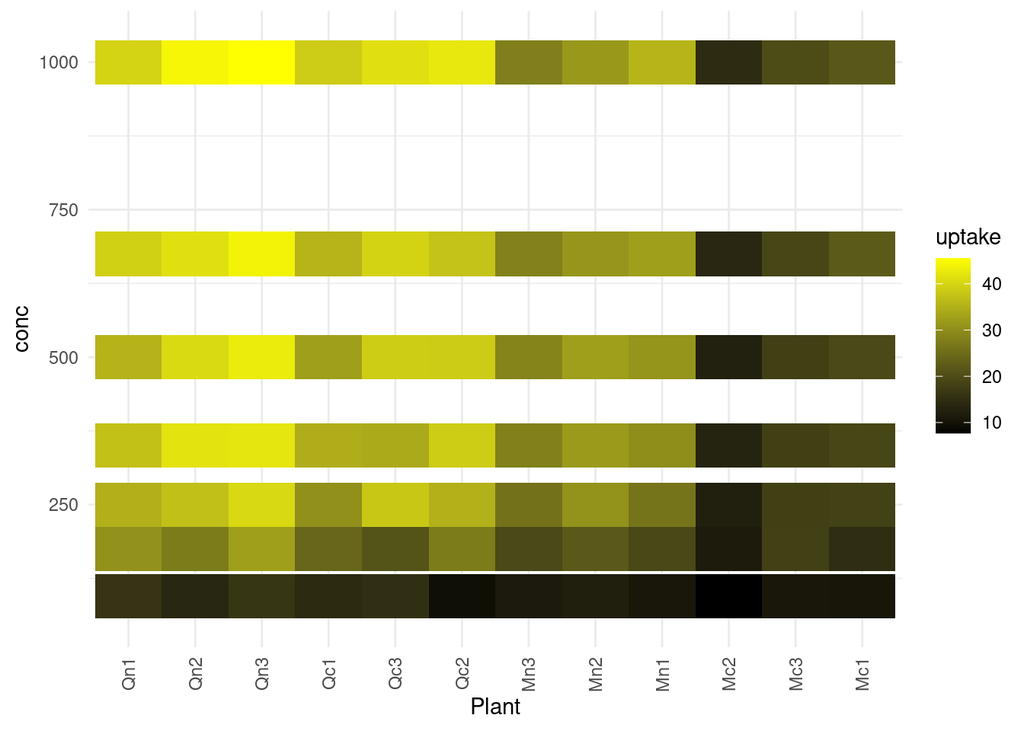

```r
data <- datasets::CO2

save1 <- ggplot(data, aes(Plant, conc, fill= uptake)) +
              geom_tile() +
              scale_fill_gradient(low = "black", high = "yellow") +
              theme_minimal() +
              theme(axis.text.x = element_text(angle = 90, vjust = 0.5, hjust=1)) #+
              # facet_wrap(data$Treatment)

save1
```

Hier zie ik dan meerdere oplopende lijnen naast elkaar. Ik denk dat bij deze het veel beter in een lijngrafiek past.

Het lijkt dat als je meestal een heatmap voor een dataset gebruikt, dat er dan vaak een ander soort visualisatiemethode ook mogelijk is, maar de heatmap voegt dan nog een extra as toe. Heatmaps zijn dan meestal een goede keuze om data te visualiseren, maar vaak zijn er andere mogelijkheden die overzichtelijker zijn doordat ze geen extra as hebben.

## May 23 2024

Vandaag wil ik verder met het maken van de presentatie

Ik wil nu een leuke heatmap om een overzichtelijk voorbeeld te hebben om makkelijk uit te leggen wat een heatmap is

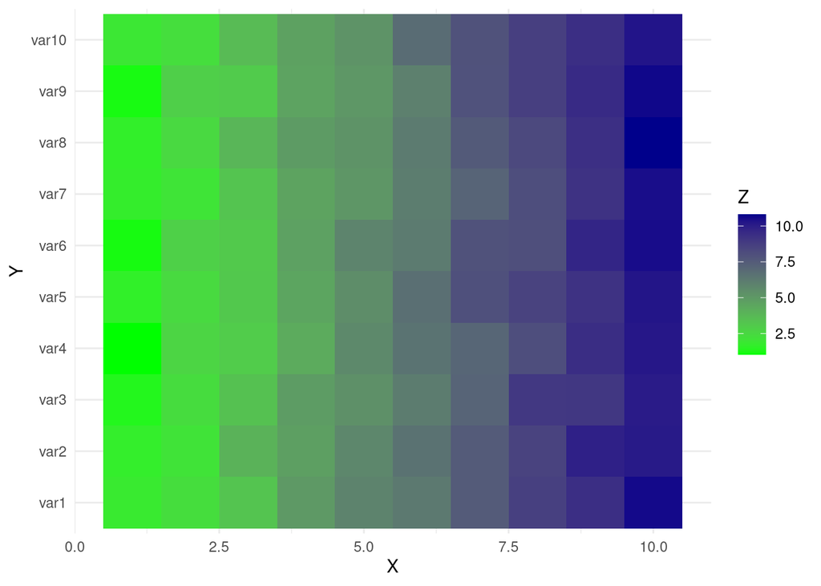

```r
x <- 1:10
y <- paste0("var", seq(1:10))
data <- expand.grid(X=x, Y=y)

Z <- 1:10 + runif(10)
for (i in 1:9){
    add <- 1:10 + runif(10)
  Z <- append(Z, add)
}

data$Z <- Z

ggplot(data, aes(X, Y, fill = Z)) +
    geom_tile() +
    scale_fill_gradient(low = "green", high = "darkblue") +
    theme_minimal()
```

Deze lijkt mij makkelijk te lezen, dus deze ga ik gebruiken

Ik denk nu ook dat er misschien meer gaten komen als je de X- of Y-as een numerieke variable maakt. Dit kan ik het makkelijkste testen met onze eigen testdata:

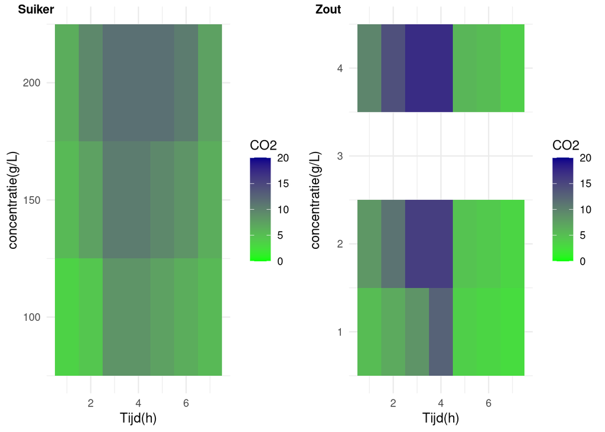

```r
# de plots die ik ook maak op lijn 128, maar deze keer verander ik het ID met de Concentratie
suiker_plot <- ggplot(data = viz_suiker_df,
            mapping = aes(x = Meting, y = Suiker, fill = CO2)) +
            geom_tile() +
            labs(y = "concentratie(g/L)", x = "Tijd(h)") +
            scale_fill_gradient(limits = c(0, 20), low = "green", high = "darkblue") +
            theme_minimal()

zout_plot <- ggplot(data = viz_zout_df,
            mapping = aes(x = Meting, y = Zout, fill = CO2)) +
            geom_tile() +
            labs(y = "concentratie(g/L)", x = "Tijd(h)") +
            scale_fill_gradient(limits = c(0, 20), low = "green", high = "darkblue") +
            theme_minimal()


plot_grid(suiker_plot, zout_plot, labels = c("Suiker", "Zout"), label_size = 10, align = c("v"))
```

Er lijkt bij suiker niks mis te gaan, maar bij zout kun je makkelijk zien dat wij niet een concentratie van 3g/L hebben gemeten. Wat er gebeurt is dat de stapgrote hetzelfde blijft tussen de blokken, maar dat niet alles daar ook gemeten is, alles wat dan onder dat getal valt bestaat niet, die heatmaps er zelf standaard uit laten. Het is dus beter om data categorisch in de dataframe te zetten ook al is het numeriek Wat er nier daarnaast ook nog gebeurt is dat twee metingen met dezelfde concentratie waardes samen in een vak worden gezet en daarvan wordt het gemiddelde genomen. In dit geval worden de duplo’s samengevoegt met de experimenten zelf. In sommige gevallen kan dit handig zijn, maar in dit geval wil ik wel de duplo’s zien.

Alles wat ik nu heb ben ik vrij tevreden mee, ik stop ze voor nu in de powerpoint, maar ik moet nog feedback vragen

Ik moet nog de daadwerkelijke data visualiseren, dus dat kan ik nu wel gaan doen

De data is ruwe data, dus ik moet naar een andere folder toe

```r
getwd()
```

```
## [1] "/home/user/Documents/ProjectWetenschappelijkeCyclus/analysis"
```

```r
real_suiker <- read.csv(file = "../raw_data/data_gist_suiker.csv")
real_zout <- read.csv(file = "../raw_data/data_gist_zout.csv")

head(real_suiker)
```

```
##   experiment_id meting_id temperatuur relatieve_productie cumulatieve_productie
## 1            S1         1        32.0                   0                    28
## 2            S1         2        31.4                   0                    28
## 3            S1         3        30.8                   0                    28
## 4            S1         4        30.4                  -2                    26
## 5            S1         5        30.0                   0                    26
## 6            S1         6        30.0                   2                    28
##        datum  tijd meetniveau opmerking null_waarde
## 1 2024-05-17 10:36         28                    NA
## 2 2024-05-17 11:03         28                    NA
## 3 2024-05-17 11:18         28                    NA
## 4 2024-05-17 11:36         26                    NA
## 5 2024-05-17 11:52         26                    NA
## 6 2024-05-17 12:10         28                    NA
```

```r
head(real_zout)
```

```
##   experiment_id meting_id temperatuur relatieve_productie cumulatieve_productie
## 1            Z1         1          30                   0                    38
## 2            Z1         2          30                 148                   186
## 3            Z1         3          30                  64                   250
## 4            Z1         4          30                 202                   452
## 5            Z1         5          30                  40                   492
## 6            Z1         6          30                  74                   566
##        datum  tijd meetniveau opmerking null_waarde
## 1 2024-05-17 11:50         38                    NA
## 2 2024-05-17 12:05        186                    NA
## 3 2024-05-17 12:20        250      Leeg           8
## 4 2024-05-17 12:42        210                    NA
## 5 2024-05-17 12:57        250      Leeg          26
## 6 2024-05-17 13:18        100                    NA
```

Het lijkt dat de de experimenten zijn gesorteerd op ID Ik sla het op in een andere variabele

```r
real_suiker_df <- as.data.frame(real_suiker)
real_zout_df <- as.data.frame(real_zout)

head(real_suiker_df)
```

```
##   experiment_id meting_id temperatuur relatieve_productie cumulatieve_productie
## 1            S1         1        32.0                   0                    28
## 2            S1         2        31.4                   0                    28
## 3            S1         3        30.8                   0                    28
## 4            S1         4        30.4                  -2                    26
## 5            S1         5        30.0                   0                    26
## 6            S1         6        30.0                   2                    28
##        datum  tijd meetniveau opmerking null_waarde
## 1 2024-05-17 10:36         28                    NA
## 2 2024-05-17 11:03         28                    NA
## 3 2024-05-17 11:18         28                    NA
## 4 2024-05-17 11:36         26                    NA
## 5 2024-05-17 11:52         26                    NA
## 6 2024-05-17 12:10         28                    NA
```

```r
head(real_zout_df)
```

```
##   experiment_id meting_id temperatuur relatieve_productie cumulatieve_productie
## 1            Z1         1          30                   0                    38
## 2            Z1         2          30                 148                   186
## 3            Z1         3          30                  64                   250
## 4            Z1         4          30                 202                   452
## 5            Z1         5          30                  40                   492
## 6            Z1         6          30                  74                   566
##        datum  tijd meetniveau opmerking null_waarde
## 1 2024-05-17 11:50         38                    NA
## 2 2024-05-17 12:05        186                    NA
## 3 2024-05-17 12:20        250      Leeg           8
## 4 2024-05-17 12:42        210                    NA
## 5 2024-05-17 12:57        250      Leeg          26
## 6 2024-05-17 13:18        100                    NA
```

We hebben nu wel wat variabelen die ik niet ga gebruiken datum, temperatuur en opmerking kan ik niks mee in r null_waarde en meetniveau zijn al omgezet naar cumulatieve_productie en relatieve_productie, dus die kunnen er ook uit tijd kan ik er ook uit halen, omdat meting_id makkelijker is.

```r
real_suiker_df <- real_suiker_df[c(1, 2, 4, 5)]
real_zout_df <- real_zout_df[c(1, 2, 4, 5)]

str(real_suiker_df)
```

```
## 'data.frame':    66 obs. of  4 variables:
##  $ experiment_id        : chr  "S1" "S1" "S1" "S1" ...
##  $ meting_id            : int  1 2 3 4 5 6 7 8 9 10 ...
##  $ relatieve_productie  : num  0 0 0 -2 0 2 -2 0 0 0 ...
##  $ cumulatieve_productie: num  28 28 28 26 26 28 26 26 26 26 ...
```

```r
str(real_zout_df)
```

```
## 'data.frame':    66 obs. of  4 variables:
##  $ experiment_id        : chr  "Z1" "Z1" "Z1" "Z1" ...
##  $ meting_id            : int  1 2 3 4 5 6 7 8 9 10 ...
##  $ relatieve_productie  : int  0 148 64 202 40 74 94 6 0 -2 ...
##  $ cumulatieve_productie: int  38 186 250 452 492 566 660 666 666 664 ...
```

Het valt me hier nu wel op dat de relatieve en cumulatieve productie van suiker en zout andere waardes gebruiken, suiker numeric en zout integers. Ik denk niet dat dit een probleem gaat veroorzaken bij de visualisatie, dus ik hou het zo

Nu even de summary bekijken:

```r
summary(real_suiker_df)
```

```
##  experiment_id        meting_id  relatieve_productie cumulatieve_productie
##  Length:66          Min.   : 1   Min.   :-38.00      Min.   :   8.0
##  Class :character   1st Qu.: 3   1st Qu.:  0.00      1st Qu.:  26.0
##  Mode  :character   Median : 6   Median :  0.00      Median :  28.0
##                     Mean   : 6   Mean   : 23.42      Mean   : 151.2
##                     3rd Qu.: 9   3rd Qu.:  8.00      3rd Qu.: 116.0
##                     Max.   :11   Max.   :210.00      Max.   :1043.0
```

```r
summary(real_zout_df)
```

```
##  experiment_id        meting_id  relatieve_productie cumulatieve_productie
##  Length:66          Min.   : 1   Min.   :-10.00      Min.   :  4.0
##  Class :character   1st Qu.: 3   1st Qu.:  0.00      1st Qu.:153.8
##  Mode  :character   Median : 6   Median : 20.00      Median :250.0
##                     Mean   : 6   Mean   : 41.47      Mean   :308.2
##                     3rd Qu.: 9   3rd Qu.: 60.50      3rd Qu.:492.8
##                     Max.   :11   Max.   :202.00      Max.   :807.0
```

Bij suiker is bij de relatieve en cumulatieve productie het derde kwartiel kleiner dan het gemiddelde, suiker had dus over het algemeen weinig productie maar er waren een paar uitschieters die het gemiddelde veel hoger brachten. De relatieve productie gaat hier wel in de min, wat niet mogelijk zou moeten zijn, dit gaat misschien veranderd worden, maar ik zit nu met deze data. De gemmiddelde productie van zout is hoger dan die van suiker, maar het maximum is wel lager.

De namen heb ik geen problemen mee, dus ik ga direct naar het visualiseren:

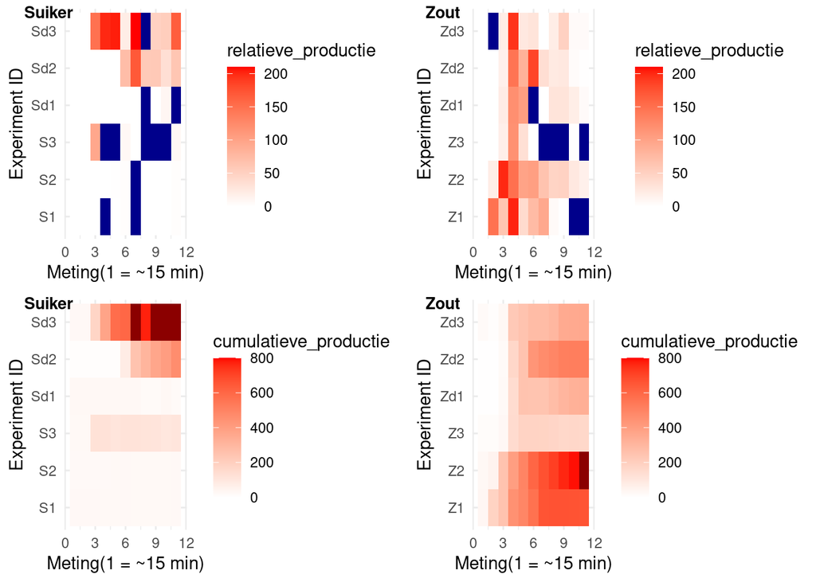

```r
# Nieuwe variabelen die ik dan makkelijk kan veranderen
real_viz_suiker_df <- real_suiker_df
real_viz_zout_df <- real_zout_df

# Ik maak hier twee verschillende heatmaps die ik later samen ga zetten
suiker_plot_rel <- ggplot(data = real_viz_suiker_df,
            mapping = aes(x = meting_id, y = experiment_id, fill = relatieve_productie)) +
            geom_tile() +
            labs(y = "Experiment ID", x = "Meting(1 = ~15 min)") +
            scale_fill_gradient(limits = c(0, 210), low = "white", high = "red", na.value = "blue4") +
            theme_minimal()

zout_plot_rel <- ggplot(data = real_viz_zout_df,
            mapping = aes(x = meting_id, y = experiment_id, fill = relatieve_productie)) +
            geom_tile() +
            labs(y = "Experiment ID", x = "Meting(1 = ~15 min)") +
            scale_fill_gradient(limits = c(0, 210), low = "white", high = "red", na.value = "blue4") +
            theme_minimal()

# Ik maak hier twee verschillende heatmaps die ik later samen ga zetten
suiker_plot_cum <- ggplot(data = real_viz_suiker_df,
            mapping = aes(x = meting_id, y = experiment_id, fill = cumulatieve_productie)) +
            geom_tile() +
            labs(y = "Experiment ID", x = "Meting(1 = ~15 min)") +
            scale_fill_gradient(limits = c(0, 800), low = "white", high = "red", na.value = "red4") +
            theme_minimal()

zout_plot_cum <- ggplot(data = real_viz_zout_df,
            mapping = aes(x = meting_id, y = experiment_id, fill = cumulatieve_productie)) +
            geom_tile() +
            labs(y = "Experiment ID", x = "Meting(1 = ~15 min)") +
            scale_fill_gradient(limits = c(0, 800), low = "white", high = "red", na.value = "red4") +
            theme_minimal()

plot_grid(suiker_plot_rel, zout_plot_rel, suiker_plot_cum, zout_plot_cum, labels = c("Suiker", "Zout", "Suiker", "Zout"), label_size = 10, align = c("hv"))
```

## May 27 2024

Ik ga vandaag weer verder met de presentatie

Daarvoor wil ik nu eerst een correlogram gaan maken.

Om makkelijk een correlogram te maken neem ik de library ggcorrplot

```r
data(mtcars)
corr <- round(cor(mtcars), 1)
head(corr[, 1:6])
```

```
##       mpg  cyl disp   hp drat   wt
## mpg   1.0 -0.9 -0.8 -0.8  0.7 -0.9
## cyl  -0.9  1.0  0.9  0.8 -0.7  0.8
## disp -0.8  0.9  1.0  0.8 -0.7  0.9
## hp   -0.8  0.8  0.8  1.0 -0.4  0.7
## drat  0.7 -0.7 -0.7 -0.4  1.0 -0.7
## wt   -0.9  0.8  0.9  0.7 -0.7  1.0
```

Hier kun je goed zien dat er all een corralatie is tussen dezelfde variabelen.

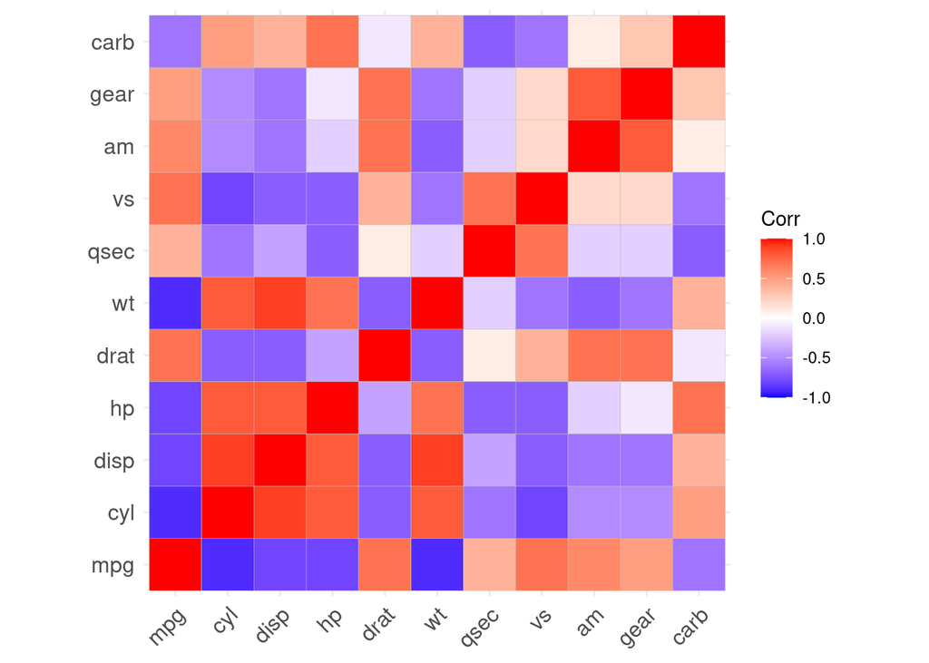

```r
ggcorrplot(corr)
```

hier heb je een corralatieplot, zoals je kan zien is de data dubbel met als scheidingslijn de rode blokjes. Dat is wel vervelend, dus ik haal de onnodige data er uit.

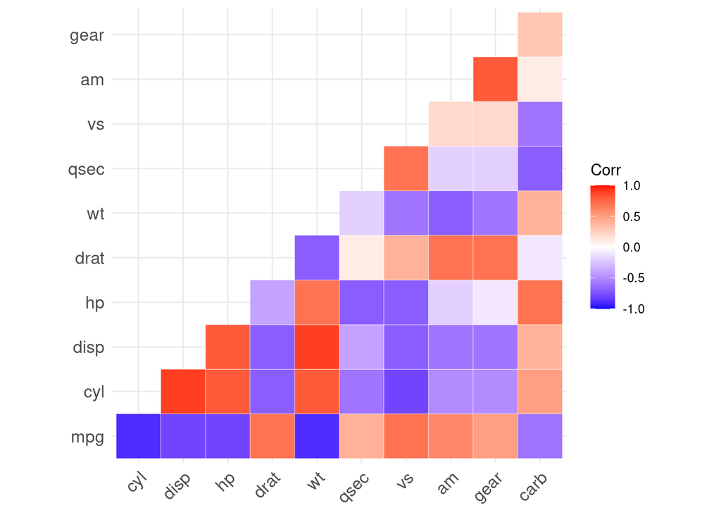

```r
ggcorrplot(corr, type = "lower", outline.color = "white", ggtheme = ggplot2::theme_minimal())
```

Met deze twee kun je goed zien wat een correlogram is, dus deze kan ik gebruiken.

Ik wil ook nog een beter voorbeeld voor een heatmap met wat na waardes en missende waardes

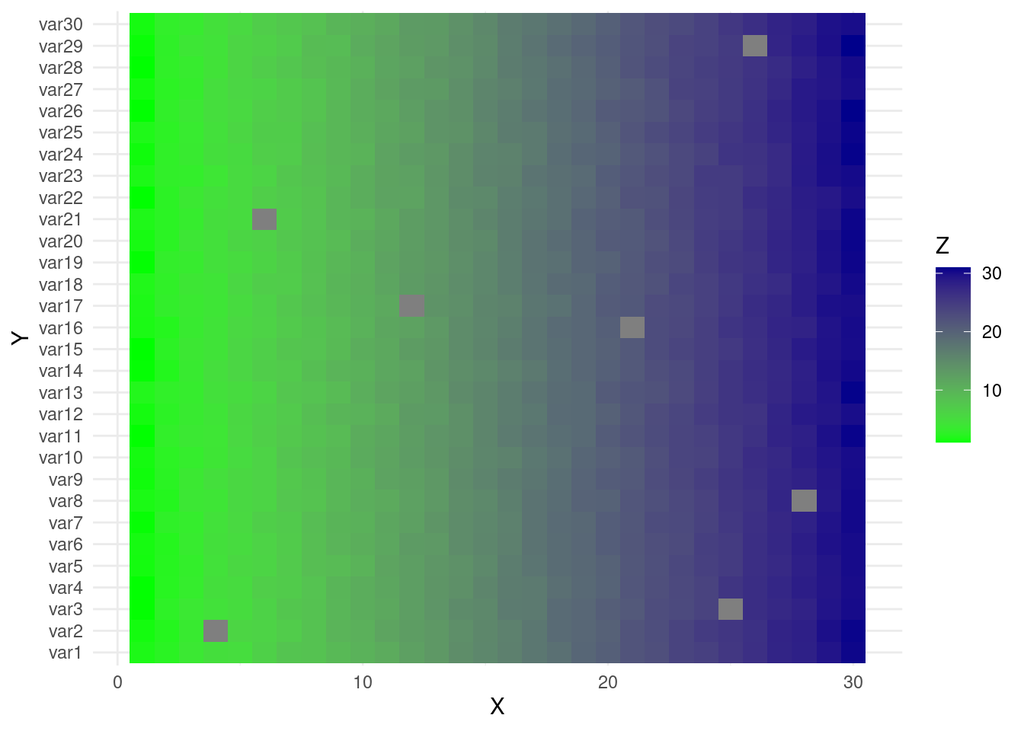

```r
x <- 1:30
y <- paste0("var", seq(1:30))
data <- expand.grid(X=x, Y=y)

Z <- 1:30 + runif(30)
for (i in 1:29){
    add <- 1:30 + runif(30)
  Z <- append(Z, add)
}

data$Z <- Z

set.seed(8243)


for (i in c(85, 606, 238, 866, 492, 34, 471)){
    data$Z[i] <- NA
}

ggplot(data, aes(X, Y, fill = Z)) +
    geom_tile() +
    scale_fill_gradient(low = "green", high = "darkblue") +
    theme_minimal()
```

Deze lijkt de NA waardes goed te laten zien

## 28 may 2024

Ik vandaag de presentatie afmaken

Ik heb ook even bedacht dat ik een correlogram van onze data maken, omdat een correlogram beter is in een one-way-anova te visualiseren en een standaard clusterd heatmap beter is in een two-way-anova te visualiseren

```r
summary(real_suiker_df)
```

```
##  experiment_id        meting_id  relatieve_productie cumulatieve_productie
##  Length:66          Min.   : 1   Min.   :-38.00      Min.   :   8.0
##  Class :character   1st Qu.: 3   1st Qu.:  0.00      1st Qu.:  26.0
##  Mode  :character   Median : 6   Median :  0.00      Median :  28.0
##                     Mean   : 6   Mean   : 23.42      Mean   : 151.2
##                     3rd Qu.: 9   3rd Qu.:  8.00      3rd Qu.: 116.0
##                     Max.   :11   Max.   :210.00      Max.   :1043.0
```

```r
summary(real_zout_df)
```

```
##  experiment_id        meting_id  relatieve_productie cumulatieve_productie
##  Length:66          Min.   : 1   Min.   :-10.00      Min.   :  4.0
##  Class :character   1st Qu.: 3   1st Qu.:  0.00      1st Qu.:153.8
##  Mode  :character   Median : 6   Median : 20.00      Median :250.0
##                     Mean   : 6   Mean   : 41.47      Mean   :308.2
##                     3rd Qu.: 9   3rd Qu.: 60.50      3rd Qu.:492.8
##                     Max.   :11   Max.   :202.00      Max.   :807.0
```

eerst moet ik dan de verschillende ID’s in een andere kolom krijgen

```r
rel_pr_suiker <- real_suiker_df[-c(4)]
rel_pr_zout <- real_viz_zout_df[-c(4)]
wider_suiker_rel <- rel_pr_suiker %>%
    pivot_wider(
        names_from = c(experiment_id),
        values_from = c(relatieve_productie)
    )
wider_zout_rel <- rel_pr_zout %>%
    pivot_wider(
        names_from = c(experiment_id),
        values_from = c(relatieve_productie)
    )
wider_suiker_rel
```

```
## # A tibble: 11 × 7
##    meting_id    S1    S2    S3   Sd1   Sd2   Sd3
##        <int> <dbl> <dbl> <dbl> <dbl> <dbl> <dbl>
##  1         1     0     0     0     0     0     0
##  2         2     0     0     0     0     0     0
##  3         3     0     0    96     0     0   149
##  4         4    -2     0    -2     0     0   200
##  5         5     0     1   -12     0     0   204
##  6         6     2     2     8     0    72    20
##  7         7    -2    -2     0     0   170   210
##  8         8     0     0    -2   -10    58   -38
##  9         9     0     0    -2     0    59    50
## 10        10     0     0   -12    10    35    54
## 11        11     2     2     8   -10    62   166
```

```r
wider_zout_rel
```

```
## # A tibble: 11 × 7
##    meting_id    Z1    Z2    Z3   Zd1   Zd2   Zd3
##        <int> <int> <int> <int> <int> <int> <int>
##  1         1     0     0     0     0     0     0
##  2         2   148    20     0     0     0   -10
##  3         3    64   200    18    21    16    20
##  4         4   202   150   118   120   146   195
##  5         5    40   100    34   105    84    25
##  6         6    74   104     0    -4   184    30
##  7         7    94    66    -2     0    36     0
##  8         8     6    47    -8    30    23    20
##  9         9     0    49    -9    30    25    50
## 10        10    -2    25     1    19     4     5
## 11        11    -2    16    -1     5     1     5
```

```r
cum_pr_suiker <- real_suiker_df[-c(4)]
cum_pr_zout <- real_viz_zout_df[-c(4)]
wider_suiker_cum <- rel_pr_suiker %>%
    pivot_wider(
        names_from = c(experiment_id),
        values_from = c(relatieve_productie)
    )
wider_zout_cum <- rel_pr_zout %>%
    pivot_wider(
        names_from = c(experiment_id),
        values_from = c(relatieve_productie)
    )
wider_suiker_cum
```

```
## # A tibble: 11 × 7
##    meting_id    S1    S2    S3   Sd1   Sd2   Sd3
##        <int> <dbl> <dbl> <dbl> <dbl> <dbl> <dbl>
##  1         1     0     0     0     0     0     0
##  2         2     0     0     0     0     0     0
##  3         3     0     0    96     0     0   149
##  4         4    -2     0    -2     0     0   200
##  5         5     0     1   -12     0     0   204
##  6         6     2     2     8     0    72    20
##  7         7    -2    -2     0     0   170   210
##  8         8     0     0    -2   -10    58   -38
##  9         9     0     0    -2     0    59    50
## 10        10     0     0   -12    10    35    54
## 11        11     2     2     8   -10    62   166
```

```r
wider_zout_cum
```

```
## # A tibble: 11 × 7
##    meting_id    Z1    Z2    Z3   Zd1   Zd2   Zd3
##        <int> <int> <int> <int> <int> <int> <int>
##  1         1     0     0     0     0     0     0
##  2         2   148    20     0     0     0   -10
##  3         3    64   200    18    21    16    20
##  4         4   202   150   118   120   146   195
##  5         5    40   100    34   105    84    25
##  6         6    74   104     0    -4   184    30
##  7         7    94    66    -2     0    36     0
##  8         8     6    47    -8    30    23    20
##  9         9     0    49    -9    30    25    50
## 10        10    -2    25     1    19     4     5
## 11        11    -2    16    -1     5     1     5
```

Nu even ze in een correlatie manier weergeven

```r
corr_rel_suiker <- round(cor(wider_suiker_rel[-1]), 1)
corr_rel_zout <- round(cor(wider_zout_rel[-1]), 1)
corr_cum_suiker <- round(cor(tail(wider_suiker_rel[-1])), 1)
corr_cum_zout <- round(cor(tail(wider_zout_cum[-1])), 1)

head(corr_rel_suiker)
```

```
##       S1   S2   S3  Sd1  Sd2  Sd3
## S1   1.0  0.9  0.1 -0.3 -0.1 -0.4
## S2   0.9  1.0  0.0 -0.3 -0.3 -0.1
## S3   0.1  0.0  1.0 -0.1 -0.2  0.2
## Sd1 -0.3 -0.3 -0.1  1.0 -0.2  0.0
## Sd2 -0.1 -0.3 -0.2 -0.2  1.0  0.2
## Sd3 -0.4 -0.1  0.2  0.0  0.2  1.0
```

```r
head(corr_cum_suiker)
```

```
##       S1   S2   S3  Sd1  Sd2  Sd3
## S1   1.0  1.0  0.6 -0.3 -0.6 -0.3
## S2   1.0  1.0  0.6 -0.3 -0.6 -0.3
## S3   0.6  0.6  1.0 -0.6  0.2  0.2
## Sd1 -0.3 -0.3 -0.6  1.0 -0.1  0.0
## Sd2 -0.6 -0.6  0.2 -0.1  1.0  0.7
## Sd3 -0.3 -0.3  0.2  0.0  0.7  1.0
```

```r
head(corr_rel_zout)
```

```
##      Z1  Z2  Z3 Zd1 Zd2 Zd3
## Z1  1.0 0.5 0.7 0.4 0.5 0.6
## Z2  0.5 1.0 0.6 0.5 0.5 0.5
## Z3  0.7 0.6 1.0 0.8 0.5 0.9
## Zd1 0.4 0.5 0.8 1.0 0.4 0.8
## Zd2 0.5 0.5 0.5 0.4 1.0 0.6
## Zd3 0.6 0.5 0.9 0.8 0.6 1.0
```

```r
head(corr_cum_zout)
```

```
##       Z1   Z2   Z3  Zd1  Zd2  Zd3
## Z1   1.0  0.8  0.3 -0.7  0.6 -0.2
## Z2   0.8  1.0  0.0 -0.5  0.9  0.4
## Z3   0.3  0.0  1.0 -0.8  0.3 -0.6
## Zd1 -0.7 -0.5 -0.8  1.0 -0.5  0.4
## Zd2  0.6  0.9  0.3 -0.5  1.0  0.3
## Zd3 -0.2  0.4 -0.6  0.4  0.3  1.0
```

Hier is de visualisatie

[figure not shown]

```r
plot_S_rel <- ggcorrplot(corr_rel_suiker, type = "lower", colors = c("blue", "black", "red"))
plot_S_cum <- ggcorrplot(corr_cum_suiker, type = "lower", colors = c("blue", "black", "red"))
plot_Z_rel <- ggcorrplot(corr_rel_zout, type = "lower", colors = c("blue", "black", "red"))
plot_Z_cum <-ggcorrplot(corr_cum_zout, type = "lower", colors = c("blue", "black", "red"))

plot_grid(plot_S_rel, plot_Z_rel, plot_S_cum, plot_Z_cum, labels = c("relatief_suiker", "relatief_zout", "cummulatief_suiker", "cummulatief_zout"), label_size = 10, align = "hv")
```

Ik stop alleen de code voor het maken van de heatmaps in een ander bestand, zoadat ik dat bestand kan gaan knitten en dat kan laten zien in de presentatie

Ik heb de visualisatie die ik heb gemaakt op 23 mei, lijn 309, uit de powerpoint gehaalt, omdat het niet echt een limitatie is. Je kunt de rij gewoon een categorisch maken en dan is het probleem weg.

## May 29 2024

Vandaag bespreek ik de presentatie met de rest zodat er nog wat kleine verbeteringen in dingen zoals plaatjes en misschien structuur kunnen komen. Uiteindelijk hebben we besloten om de achtergrond van de inleiding te veranderen en twee slides te fuseren tot een slide. Ook hebben we de reden voor het gebruiken van heatmaps op een aparte slide gezet in te plaats van het uit te leggen bij de soorten heatmaps.

We hebben vandaag ook afgesproken wie welk deel van de paper gaat schrijven. Ik ga het Materialen en Methoden stukje schrijven, omdat ik ook al het protocool heb gemaakt. Na de presentatie heb ik geen energie meer, dus ik begin er morgen aan.

## May 30 2024

Vandaag wil ik een goed begin maken aan het materialen en methoden stuk.

Ik heb het grootste gedeelte van materialen en uitvoering af, ik ga morgen verder en dat wil ik zo veel mogelijk af krijgen.

## May 31 2024

Vandaag ga ik verder met het schrijven van materialen en methoden.

Ik ben veel verder gekomen en ben bijna klaar met het stukje.

## June 2 2024

Vandaag ga ik proberen de eerste versie van materialen en methoden af te hebben

Ik heb voor feedback gevraagd van mijn vader en heb het stuk op verschillende aspecten kunnen veranderen, bijvoorbeeld om de meeste dingen in verleden tijd aan te duiden.

## June 3 2024

Vandaag wil ik wat laatste aanpassingen doen voor mijn stukje gebaseerd op wat de anderen hebben toegevoegd, dus ik ga de delen van de anderen lezen.

Het grootste gedeelte lijkt mij goed, maar ik ga wel even een link naar de repo er in zetten en een deel van de spelling veranderen.

## June 4 2024

Vandaag is de deadline, dus wij willen de paper afschrijven

Ik heb de samenvatting gemaakt